# 스타벅스_이디야_입지환경분석 1

[ 스타벅스 & 이디야 입지환경 분석 1 ]

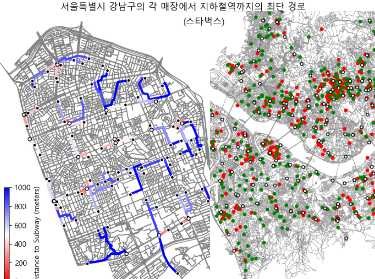

```python
Image('title001.png')
```

#### 스타벅스 인근에 전략적으로 이디야가 입점한다는 말이 있지만, 공식적인 근거는 없어서 이에 대한 다양한 분석들이 이뤄지고 있다.

#### 본 분석에서는 입지 환경적 측면, 특히 지하철역과 관련하여 두 브랜드의 위치적 관련성을 분석해 본다. 아래 두 파트로 진행해 보았다.

#### ● 서울시 구별 스타벅스 이디야 매장 입지환경 분석 ( 공시지가, 지하철역수, 매장수, 총생활인구수 )

#### ● 이디야 & 컴포지 비교

# 전처리 데이터셋 생성

```python
import os
import geopandas as gpd
import osmnx as ox
import networkx as nx
from shapely.geometry import Point

import numpy as np
import pandas as pd
from tqdm import tqdm
import matplotlib.pyplot as plt

from pyproj import Transformer
from matplotlib.colors import TwoSlopeNorm

from IPython.display import clear_output
from IPython.display import Image

import pickle

import warnings
warnings.filterwarnings(action='ignore')
import sys
#sys.stdout = open(os.devnull, 'w')
sys.stderr = open(os.devnull, 'w')
root = os.getcwd()

pd.options.display.float_format = '{:.0f}'.format
plt.rcParams['font.family'] = 'Malgun Gothic'
```

#### 지하철역, 스타벅스 매장, 이디야 매장 공간데이터

subway 공간데이터

```python
with open("subway_name.pickle","rb") as fi:
    subway_name = pickle.load(fi)
subway_name = subway_name.rename(columns={'subway_name' : 'SUBWAY_STA'} )
data_path = os.path.join(root, 'subway_statn_info')
subway = gpd.read_file(os.path.join(data_path,'subway_statn_info.shp'),encoding='EUC-KR')
subway['SUBWAY_STA'] = subway_name['SUBWAY_STA']
subway.head()
```

|  | SUBWAY_STA | OPNG_YMD | SUBWAY__01 | geometry |
| --- | --- | --- | --- | --- |
| 0 | 온수역 | None | 57 | POINT (184330.338 443625.386) |
| 1 | 천왕역 | None | 58 | POINT (185637.754 443167.709) |
| 2 | 남구로역 | None | 59 | POINT (190001.728 442926.56) |
| 3 | 구로디지털단지역 | 20070807 | 60 | POINT (191231.554 442905.09) |
| 4 | 도림천역 | None | 142 | POINT (189654.644 446092.355) |

```python
# 지하철역 좌표추출
subway = subway.to_crs(epsg=5179) # 좌표계 변환
sub_crds = [[list(subway.geometry[i].coords)[0][0], list(subway.geometry[i].coords)[0][1]] for i in range(len(subway))]
sub_crds_arr = np.array(sub_crds)
```

스타벅스 이디야 공간데이터

```python
ediya = pd.read_csv('ediya.csv')
starbucks = pd.read_csv('starbucks.csv')
```

```python
# 좌표계 변환
transformer = Transformer.from_crs("epsg:4326", "epsg:5179", always_xy=True)
ediya['longitude'],ediya['latitude'] = transformer.transform(ediya['lng'],ediya['lat'])
starbucks['longitude'],starbucks['latitude'] = transformer.transform(starbucks['lng'],starbucks['lat'])
```

```python
ediya = ediya[['gu','title','address','lat','lng','longitude','latitude']]
geometry = [Point(xy) for xy in zip(ediya['longitude'], ediya['latitude'])]
ediya_geo = gpd.GeoDataFrame(ediya, geometry=geometry)
ediya_geo.head()
```

|  | gu | title | address | lat | lng | longitude | latitude | geometry |
| --- | --- | --- | --- | --- | --- | --- | --- | --- |
| 0 | 강남구 | 강남YMCA점 | 서울 강남구 논현동 | 38 | 127 | 958615 | 1946147 | POINT (958615.456 1946146.863) |
| 1 | 강남구 | 강남구청역아이티웨딩점 | 서울 강남구 학동로 338 (논현동, 강남파라곤) | 38 | 127 | 959362 | 1946462 | POINT (959361.721 1946461.887) |
| 2 | 강남구 | 강남논현학동점 | 서울 강남구 논현로131길 28 (논현동) | 38 | 127 | 958249 | 1946316 | POINT (958248.791 1946316.358) |
| 3 | 강남구 | 강남대치점 | 서울 강남구 역삼로 415 (대치동, 성진빌딩) | 38 | 127 | 960431 | 1944780 | POINT (960430.89 1944779.522) |
| 4 | 강남구 | 강남도산점 | 서울 강남구 도산대로37길 20 (신사동) | 38 | 127 | 958600 | 1947101 | POINT (958599.662 1947101.46) |

```python
starbucks = starbucks[['구','title','address','lat','lng','longitude','latitude']]
starbucks = starbucks.rename(columns={'구' : 'gu'})
geometry = [Point(xy) for xy in zip(starbucks['longitude'], starbucks['latitude'])]
starbucks_geo = gpd.GeoDataFrame(starbucks, geometry=geometry)
starbucks_geo.head()
```

|  | gu | title | address | lat | lng | longitude | latitude | geometry |
| --- | --- | --- | --- | --- | --- | --- | --- | --- |
| 0 | 강남구 | 역삼아레나빌딩 | 서울특별시 강남구 언주로 425 (역삼동) | 38 | 127 | 959612 | 1944745 | POINT (959612.309 1944744.958) |
| 1 | 강남구 | 논현역사거리 | 서울특별시 강남구 강남대로 538 (논현동) | 38 | 127 | 957775 | 1945763 | POINT (957774.861 1945762.698) |
| 2 | 강남구 | 신사역성일빌딩 | 서울특별시 강남구 강남대로 584 (논현동) | 38 | 127 | 957634 | 1946180 | POINT (957634.047 1946179.786) |
| 3 | 강남구 | 국기원사거리 | 서울특별시 강남구 테헤란로 125 (역삼동) | 37 | 127 | 958588 | 1944576 | POINT (958588.421 1944575.806) |
| 4 | 강남구 | 대치재경빌딩 | 서울특별시 강남구 남부순환로 2947 (대치동) | 37 | 127 | 961334 | 1944025 | POINT (961333.832 1944024.617) |

#### 도로네트워크'와의 매핑

도로네트워크 공간데이터

```python
with open('G_utm.pkl', 'rb') as file:
    G_utm = pickle.load(file)
```

'지하철역 & 스벅/이디야'과 '도로네트워크(G_utm)'와의 매핑

```python
nearest_sub, dist_sub = ox.distance.nearest_nodes(G_utm, X=sub_crds_arr[:,0], Y=sub_crds_arr[:,1], return_dist=True)
nearest_sb, dist_sb      = ox.distance.nearest_nodes(G_utm, X=starbucks['longitude'], Y=starbucks['latitude'], return_dist=True)
nearest_id, dist_id      = ox.distance.nearest_nodes(G_utm, X=ediya['longitude'], Y=ediya['latitude'], return_dist=True)
```

nearest( G_utm 노드)에 해당하는 G_utm의 index추출

```python
G_utm_nodes = list(G_utm.nodes)
subway_idx = [G_utm_nodes.index(nearest_sub[i]) for i in range(len(nearest_sub))]
sb_idx = [G_utm_nodes.index(nearest_sb[i]) for i in range(len(nearest_sb))]
id_idx = [G_utm_nodes.index(nearest_id[i]) for i in range(len(nearest_id))]
```

#### 데이터셋 : 구별 경계 지도 데이터 + 스타벅스&이디야 데이터 + 지하철역 데이터 + 공시지가 데이터

구별 경계 지도 데이터

```python
si_file = "./sig_emd/sig_20230729/sig.shp"
sigu = gpd.read_file(si_file, encoding='euckr')
sigu = sigu.set_crs(epsg=5179) # sigu 수동으로 좌표계를 설정
```

서울만 추출 & 스타벅스&이디야 지하철 데이터 합치기

```python
sigu['CTPRVN_CD'] = [str(num)[:2] for num in sigu['SIG_CD']]
sigu = sigu.loc[sigu['CTPRVN_CD']=='11']
starbucks_count = starbucks_geo.groupby('gu').size().reset_index(name='starbucks_count')
starbucks_count = starbucks_count.rename(columns={'gu' : 'SIG_KOR_NM'} )
ediya_count = ediya_geo.groupby('gu').size().reset_index(name='ediya_count')
ediya_count = ediya_count.rename(columns={'gu' : 'SIG_KOR_NM'} )
sigu = sigu.merge(starbucks_count, on='SIG_KOR_NM')
sigu = sigu.merge(ediya_count, on='SIG_KOR_NM')
```

스타벅스&이디야 매장 수 차이 변수 생성

```python
sigu['sb_id'] = sigu['starbucks_count']-sigu['ediya_count']
for index, rows in sigu.iterrows():
    if rows['sb_id']>0:
        sigu.at[index, 'sb_id_1']= "SB: +"+str(rows['sb_id'])
    elif rows['sb_id']==0:
        sigu.at[index, 'sb_id_1']= "동일"
    else:
        sigu.at[index, 'sb_id_1']= "ED: +"+str(rows['sb_id']*-1)
```

공시지가 데이터

```python
with open("rprice.pickle","rb") as fi:
    rprice = pickle.load(fi)
rprice['공시지가'] = rprice['공시지가'].astype(float)
rprice = rprice[rprice['시도명']=="서울특별시"]
rprice_gu = rprice.groupby('시군구명')['공시지가'].mean().reset_index(name='공시지가 평균')
rprice_gu = rprice_gu.rename(columns={'시군구명' : 'SIG_KOR_NM'} )
sigu = sigu.merge(rprice_gu, on='SIG_KOR_NM')
```

구별 지하철역 수

```python
gu_sub = pd.read_csv('서울교통공사_자치구별지하철역정보_20240628.csv',encoding='euckr')
gu_sub = gu_sub.rename(columns={'자치구' : 'SIG_KOR_NM'} )
sigu = sigu.merge(gu_sub.drop(columns = ['해당역(호선)']), on='SIG_KOR_NM')
```

구별 생활인구데이터(일평균)

```python
lifepup = pd.read_csv('./서울행정동코드/서울_생활인구데이터_행정동별_202407.csv',encoding='EUC-KR')
lifepup = lifepup.drop(columns = ['Unnamed: 0'])
lifepup = lifepup.rename(columns={'시군구명' : 'SIG_KOR_NM'} )
lifepup_1 = lifepup.groupby('SIG_KOR_NM')['총생활인구수_평균'].sum().reset_index(name='총생활인구수_평균')
sigu = sigu.merge(lifepup_1, on='SIG_KOR_NM')
sigu.head()
```

|  | SIG_CD | SIG_ENG_NM | SIG_KOR_NM | geometry | CTPRVN_CD | starbucks_count | ediya_count | sb_id | sb_id_1 | 공시지가 평균 | 역개수 | 총생활인구수_평균 |
| --- | --- | --- | --- | --- | --- | --- | --- | --- | --- | --- | --- | --- |
| 0 | 11110 | Jongno-gu | 종로구 | POLYGON ((956615.453 1953567.199, 956621.579 1... | 11 | 39 | 35 | 4 | SB: +4 | 5938143 | 15 | 270198 |
| 1 | 11140 | Jung-gu | 중구 | POLYGON ((957890.386 1952616.746, 957909.908 1... | 11 | 52 | 34 | 18 | SB: +18 | 9949269 | 23 | 266110 |
| 2 | 11170 | Yongsan-gu | 용산구 | POLYGON ((953115.761 1950834.084, 953114.206 1... | 11 | 24 | 13 | 11 | SB: +11 | 6812485 | 10 | 269828 |
| 3 | 11200 | Seongdong-gu | 성동구 | POLYGON ((959681.109 1952649.605, 959842.412 1... | 11 | 14 | 20 | -6 | ED: +6 | 4884766 | 14 | 330137 |
| 4 | 11215 | Gwangjin-gu | 광진구 | POLYGON ((964825.058 1952633.25, 964875.565 19... | 11 | 19 | 20 | -1 | ED: +1 | 4371127 | 11 | 348459 |

# 서울시 구별 스타벅스 이디야 매장 입지환경 분석

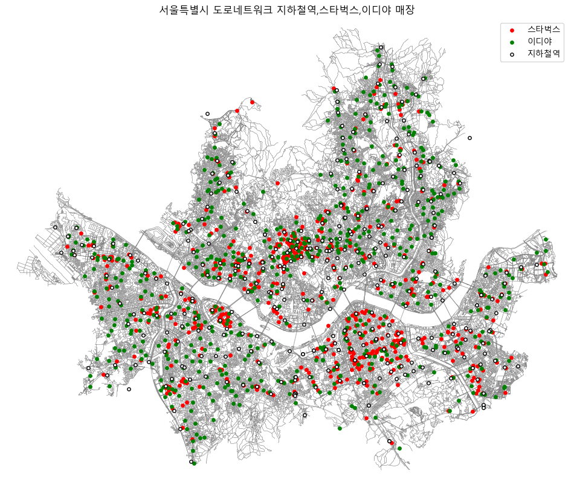

```python
gutm_locat_3p(G_utm,starbucks,ediya,sub_crds_arr,'스타벅스','이디야','지하철역','서울특별시 도로네트워크 지하철역,스타벅스,이디야 매장')
```

### 1. 입지환경 - 공시지가, 지하철역수, 매장수

#### 상관계수 - 공시지가, 지하철역수, 이디아 스타벅스 매장수

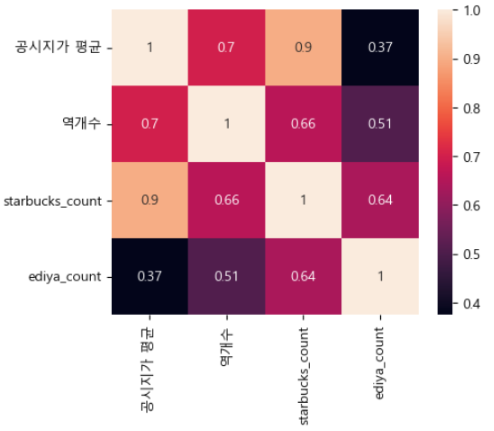

```python
Image('상관계수01.png')
```

#### 1_1. 서울 구별 공시지가

공시지가 중간값: 3,986,627원(관악구), 공시지가 최소: 2,390,374원(도봉구), 공시지가 최대: 11,925,742원(강남구)

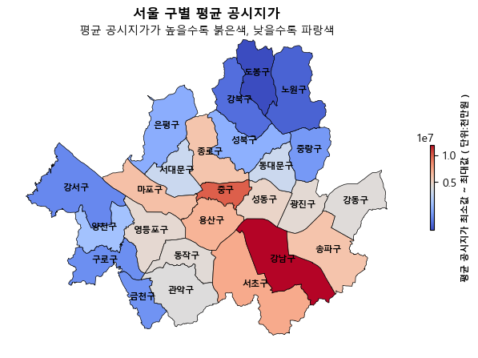

```python
add_text_sb = "평균 공시지가가 높을수록 붉은색, 낮을수록 파랑색"
title_text = "서울 구별 평균 공시지가"
map_color_text(sigu,'공시지가 평균','coolwarm','평균 공시지가 최소값 ~ 최대값 ( 단위:천만원 )','SIG_KOR_NM',add_text_sb,title_text)
```

#### 1_2. 서울 구별 지하철역 수

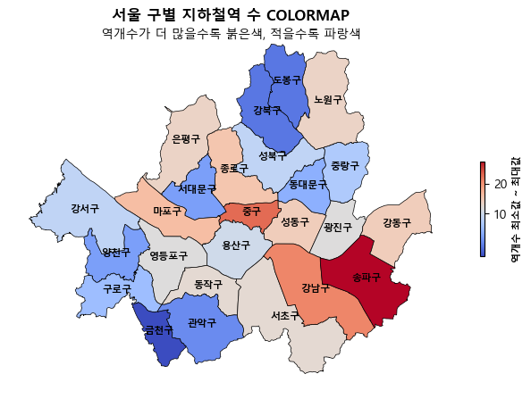

```python
add_text_sb = '역개수가 더 많을수록 붉은색, 적을수록 파랑색'
title_text = '서울 구별 지하철역 수 COLORMAP'
map_color_text(sigu,'역개수','coolwarm','역개수 최소값 ~ 최대값','SIG_KOR_NM',add_text_sb,title_text)
```

#### 1_3. 서울 구별 '스타벅스'&'이디야' 매장 수

스타벅스 매장 수: 614, 이디야 매장수: 686 ( 이디야가 72개 더 많다.)

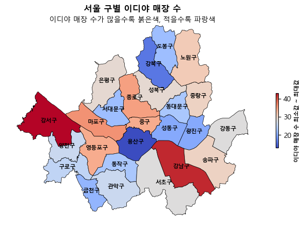

```python
add_text_sb = '이디야 매장 수가 많을수록 붉은색, 적을수록 파랑색'
title_text = "서울 구별 이디야 매장 수"
map_color_text(sigu,'ediya_count','coolwarm','이디야 매장 수 최소값 ~ 최대값','SIG_KOR_NM',add_text_sb,title_text)
```

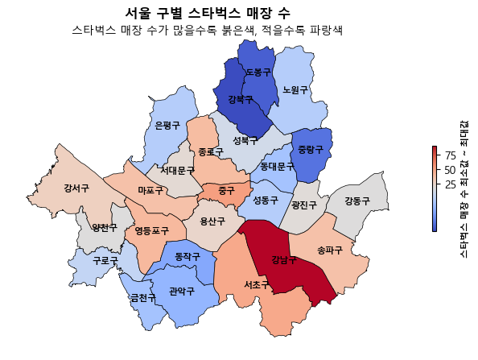

```python
add_text_sb = '스타벅스 매장 수가 많을수록 붉은색, 적을수록 파랑색'
title_text = "서울 구별 스타벅스 매장 수"
map_color_text(sigu,'starbucks_count','coolwarm','스타벅스 매장 수 최소값 ~ 최대값','SIG_KOR_NM',add_text_sb,title_text)
```

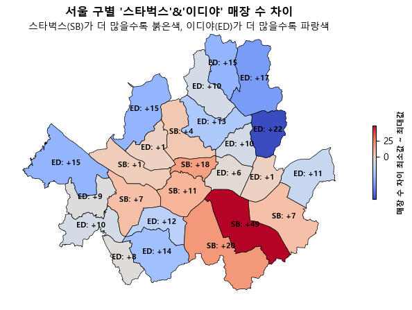

```python
add_text_sb = '스타벅스(SB)가 더 많을수록 붉은색, 이디야(ED)가 더 많을수록 파랑색'
title_text = "서울 구별 '스타벅스'&'이디야' 매장 수 차이"
map_color_text(sigu,'sb_id','coolwarm','매장 수 차이 최소값 ~ 최대값','sb_id_1',add_text_sb,title_text)
```

#### ● 공시지가가 높은 구 그리고, 지하철역이 많은 구에 스타벅스 매장 수가 많이 분포되어 있다.

#### ● 이디야의 경우 공시지가가 높고 지하철역수가 많은 구에 매장이 많이 분포되어 있다고는 볼 수 없다.

### 2. 입지환경 - 스타벅스 & 이디야 매장에서 지하철역까지의 최단거리 분석 ( 각 매장에서 1000미터 이내 )

스타벅스 최근접 지하철역 & 거리

```python
starbucks_1 = nearest_fun(G_utm,nearest_sb,nearest_sub,starbucks)
```

이디야 최근접 지하철역 & 거리

```python
ediya_1 = nearest_fun(G_utm,nearest_id,nearest_sub,ediya)
```

#### 구별 평균 최단거리 생성 & 데이터셋 합치기

```python
sb_gu_mean = starbucks_1.groupby('gu')['dist2sub'].mean().reset_index()
sb_gu_mean = sb_gu_mean.sort_values(by='dist2sub', ascending=True)
id_gu_mean = ediya_1.groupby('gu')['dist2sub'].mean().reset_index()
id_gu_mean = id_gu_mean.sort_values(by='dist2sub', ascending=True)
sb_gu_mean = sb_gu_mean.rename(columns={'gu' : 'SIG_KOR_NM'} )
id_gu_mean = id_gu_mean.rename(columns={'gu' : 'SIG_KOR_NM'} )
sb_gu_mean = sb_gu_mean.rename(columns={'dist2sub' : '평균거리_sb'} )
id_gu_mean = id_gu_mean.rename(columns={'dist2sub' : '평균거리_ed'} )
sigu = sigu.merge(sb_gu_mean, on='SIG_KOR_NM')
sigu = sigu.merge(id_gu_mean, on='SIG_KOR_NM')
# 이디야 최단거리(평균) - 스타벅스 최단거리(평균)
sigu['평균거리_차이'] = sigu['평균거리_ed']-sigu['평균거리_sb']
sigu.head()
```

|  | SIG_CD | SIG_ENG_NM | SIG_KOR_NM | geometry | CTPRVN_CD | starbucks_count | ediya_count | sb_id | sb_id_1 | 공시지가 평균 | 역개수 | 총생활인구수_평균 | 평균거리_sb | 평균거리_ed | 평균거리_차이 |
| --- | --- | --- | --- | --- | --- | --- | --- | --- | --- | --- | --- | --- | --- | --- | --- |
| 0 | 11110 | Jongno-gu | 종로구 | POLYGON ((956615.453 1953567.199, 956621.579 1... | 11 | 39 | 35 | 4 | SB: +4 | 5938143 | 15 | 270198 | 404 | 429 | 25 |
| 1 | 11140 | Jung-gu | 중구 | POLYGON ((957890.386 1952616.746, 957909.908 1... | 11 | 52 | 34 | 18 | SB: +18 | 9949269 | 23 | 266110 | 377 | 415 | 38 |
| 2 | 11170 | Yongsan-gu | 용산구 | POLYGON ((953115.761 1950834.084, 953114.206 1... | 11 | 24 | 13 | 11 | SB: +11 | 6812485 | 10 | 269828 | 496 | 530 | 34 |
| 3 | 11200 | Seongdong-gu | 성동구 | POLYGON ((959681.109 1952649.605, 959842.412 1... | 11 | 14 | 20 | -6 | ED: +6 | 4884766 | 14 | 330137 | 396 | 469 | 73 |
| 4 | 11215 | Gwangjin-gu | 광진구 | POLYGON ((964825.058 1952633.25, 964875.565 19... | 11 | 19 | 20 | -1 | ED: +1 | 4371127 | 11 | 348459 | 368 | 580 | 212 |

#### 상관계수 - 공시지가, 지하철역수, 최단거리 차이, 매장수 차이

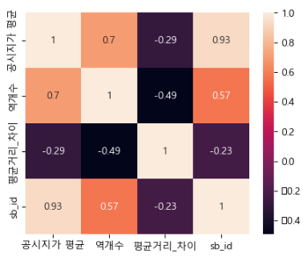

```python
Image('상관계수02.png')
```

( sb_id : 스타벅스 이디야 매장 수 차이 )

#### 2_1. 매장에서 지하철역까지 최단거리 구별 평균

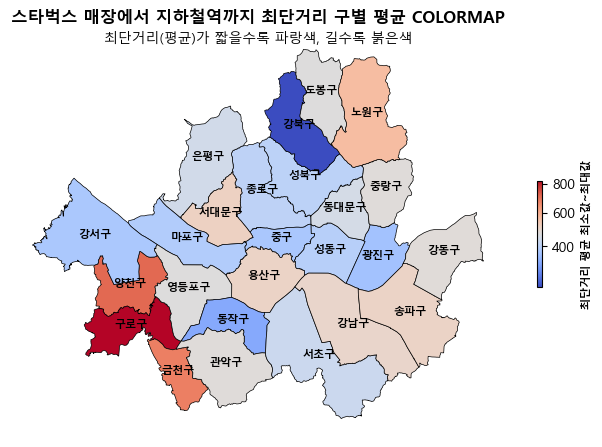

```python
add_text_sb = '최단거리(평균)가 짧을수록 파랑색, 길수록 붉은색'
title_text = '스타벅스 매장에서 지하철역까지 최단거리 구별 평균 COLORMAP'
map_color_text(sigu,'평균거리_sb','coolwarm','최단거리 평균 최소값~최대값','SIG_KOR_NM',add_text_sb,title_text)
```

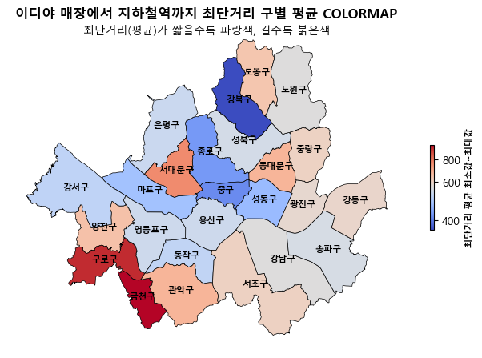

```python
add_text_sb = '최단거리(평균)가 짧을수록 파랑색, 길수록 붉은색'
title_text = '이디야 매장에서 지하철역까지 최단거리 구별 평균 COLORMAP'
map_color_text(sigu,'평균거리_ed','coolwarm','최단거리 평균 최소값~최대값','SIG_KOR_NM',add_text_sb,title_text)
```

#### 2_2. 이디야 최단거리(평균) & 스타벅스 최단거리(평균) 차이

```python
sigu['평균거리_ed'].mean(),sigu['평균거리_sb'].mean(),sigu['평균거리_차이'].mean()
```

```
(583.5464143802974, 464.65921912733813, 118.8871952529592)
```

이디야의 평균 최단거리가 스타벅스보다 119m 더 길다.

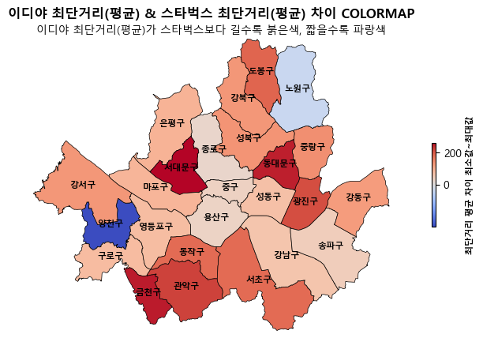

```python
add_text_sb = '이디야 최단거리(평균)가 스타벅스보다 길수록 붉은색, 짧을수록 파랑색'
title_text = '이디야 최단거리(평균) & 스타벅스 최단거리(평균) 차이 COLORMAP'
map_color_text1(sigu,'평균거리_차이','coolwarm','최단거리 평균 차이 최소값~최대값','SIG_KOR_NM',add_text_sb,title_text)
```

#### ● 서울 대부분의 구에서 스타벅스가 이디야보다 지하철역까지의 최단거리(평균)가 더 짧다.

#### ● 두 브랜드 매장에서 전철역까지 최단거리 차이에 있어서 공시지가가 높은 구, 지하철역이 많은 구에서는 차이가 작게 나타난다.

#### ● 공시지가가 높은 구, 지하철역이 많은 구에서 스타벅스의 매장 수가 이디야보다 더 많다.

### 3. 입지환경 - 총생활인구수

#### 3_1. 서울특별시 구별 총생활인구수

총생활인구수(일평균) 중앙값 : 동작구 362,771명  
총생활인구수(일평균) 최대값 : 강남구 850,670명  
총생활인구수(일평균) 최소값 : 금천구 219,840명

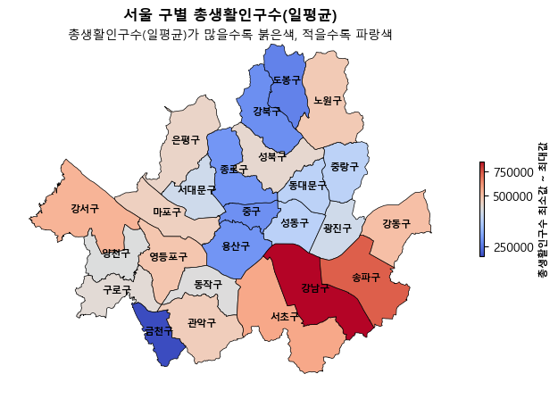

```python
add_text_sb = '총생활인구수(일평균)가 많을수록 붉은색, 적을수록 파랑색'
title_text = "서울 구별 총생활인구수(일평균)"
map_color_text(sigu,'총생활인구수_평균','coolwarm','총생활인구수 최소값 ~ 최대값','SIG_KOR_NM',add_text_sb,title_text)
```

#### ● 총생활인구수의 경우 강북에 위치한 구들이 강남보다 대체로 적다.

### 함수 코드

```python
def gutm_locat_3p(G_utm,starbucks,ediya,sub_crds_arr,label1,label2,label3,title):
    import matplotlib.cm as cm
    import matplotlib.colors as mcolors

    fig, ax = plt.subplots(figsize=(12, 12))
    ox.plot_graph(G_utm, ax=ax, node_size=0, edge_color='gray',edge_linewidth=0.25, show=False, close=False)
    cmap = cm.get_cmap('Reds_r')# 진한 붉은색에서 연한 붉은색으로,'Reds' : 연한 붉은색에서 진한 붉은색으로
    norm = mcolors.Normalize(vmin=0, vmax=1000)  # 1000 미터를 기준으로 정규화
    ax.scatter( starbucks['longitude'],starbucks['latitude'], color='red', s=15, alpha=1, zorder=1,label=label1)
    ax.scatter( ediya['longitude'],ediya['latitude'], color='green', s=15, alpha=1, zorder=1,label=label2)
    ax.scatter(sub_crds_arr[:, 0], sub_crds_arr[:, 1], color='white', s=15, alpha=1, zorder=1, edgecolor='black',label=label3)
    plt.legend(loc='upper right')

    plt.title(title)
    plt.show()

def map_color_text(sigu,var,colorm,cbar_label,var1,additional_text,title ):
    from matplotlib.colors import TwoSlopeNorm
    norm = TwoSlopeNorm(vmin=min(sigu[var]), vcenter =sigu[var].median() , vmax=max(sigu[var]))

    # 시각화
    #fig, ax = plt.subplots(1, 1, figsize=(10,7))
    fig, ax = plt.subplots(1, 1, figsize=(8,5.5))
    base = sigu.plot(column=var, ax=ax, legend=False, cmap=colorm, edgecolor='k', linewidth=0.5, norm=norm)

    sm = plt.cm.ScalarMappable(cmap=colorm, norm=norm)
    sm._A = []
    cbar = fig.colorbar(sm, ax=ax, shrink=0.25)  # shrink 매개변수로 높이 축소
    cbar.set_label(cbar_label, fontsize=8, weight='bold')

    for idx, row in sigu.iterrows():
        plt.text(row.geometry.centroid.x, row.geometry.centroid.y,row[var1],#"test",
                 horizontalalignment='center', fontsize=8, color='black', weight='bold')

    plt.text(0.5,0.98, additional_text, ha='center', va='center', transform=ax.transAxes, fontsize=10)
    ax.set_axis_off()
    ax.set_title(title, fontsize=12, weight='bold')
    plt.show()

def map_color_text1(sigu,var,colorm,cbar_label,var1,additional_text,title ):
    from matplotlib.colors import TwoSlopeNorm
    norm = TwoSlopeNorm(vmin=min(sigu[var]), vcenter = 0 , vmax=max(sigu[var]))

    #fig, ax = plt.subplots(1, 1, figsize=(10,7))
    fig, ax = plt.subplots(1, 1, figsize=(8,5.5))
    base = sigu.plot(column=var, ax=ax, legend=False, cmap=colorm, edgecolor='k', linewidth=0.5, norm=norm)

    sm = plt.cm.ScalarMappable(cmap=colorm, norm=norm)
    sm._A = []
    cbar = fig.colorbar(sm, ax=ax, shrink=0.25)
    cbar.set_label(cbar_label, fontsize=8, weight='bold')

    for idx, row in sigu.iterrows():
        plt.text(row.geometry.centroid.x, row.geometry.centroid.y,row[var1],#"test",
                 horizontalalignment='center', fontsize=8, color='black', weight='bold')
    plt.text(0.5,0.98, additional_text, ha='center', va='center', transform=ax.transAxes, fontsize=10)
    ax.set_axis_off()
    ax.set_title(title, fontsize=12, weight='bold')
    plt.show()

def nearest_fun(G_utm,nearest_sb,nearest_sub,df):
    shortest_dist2sub = []
    shortest_dist2sub_p = []
    for i in tqdm(range(len(nearest_sb))):
        centroid_point = (G_utm.nodes[nearest_sb[i]]['x'], G_utm.nodes[nearest_sb[i]]['y'])
        buffer = Point(centroid_point).buffer(1000)
        # 1000미터 이내의 지하철역 찾기 ======================================================================
        temp = []
        temp_sub = []
        for j in range(len(nearest_sub)):
            subway_point_xy = (G_utm.nodes[nearest_sub[j]]['x'], G_utm.nodes[nearest_sub[j]]['y'])
            if buffer.contains(Point(subway_point_xy)):
                try:
                    dist = nx.shortest_path_length(G_utm, nearest_sb[i], nearest_sub[j],weight='length')
                    temp.append(dist)
                    temp_sub.append(nearest_sub[j])
                except:
                    pass
        if len(temp) > 0 :
            shortest_dist2sub.append(min(temp))
            shortest_dist2sub_p.append(temp_sub[temp.index(min(temp))])
        else:
            shortest_dist2sub.append(None)
            shortest_dist2sub_p.append(None)

    df['dist2sub'] = shortest_dist2sub
    df['dist2sub_p'] = shortest_dist2sub_p
    return(df)
```